# Proposal:Detecting Fraud in Election by Data Analysis

Richard

January 29, 2016

**Abstract**

This research focuses on the interdisciplinary field of data science and political science, and explores the application of statistical methods to the detection of fraud in political elections. Inspired by Dr. Eric Meyersson’s statistical analysis of the Turkish mayoral election in 2014, this paper intends to develop a quantitative method to calculate the confidence about whether the fraud was commited, and apply the method to other elections of various scope.

**Introduction**

Election, as a representation of free will and democracy among people, exists widely around the world. The most common election that involves millions of people is the presidential election, in which the government gathers the choice for the leadership from each invidual, summarizes the comprehensive result, and determines whom the next leader will be. Although the method of election may vary from countries to countries, the basic voting process remains similar. In each major election across the whole country, every person will register for a vote, go to the voting office, and hand in the vote. Thus, there exists three numbers of votes for each step: number of registered votes, number of people who are observed to go to the office, and number of valid votes in the end.

The election fraud have two possibilities to happen, either commited by people during the voting process or commited by the government officers after the voting process. Because governors will observe each voter at different poll, but will not be observed on the backstage, the possibility that fraud happens inside the government itself is comparably high.

The detection of fraud has a high level of importance because the addition of fake votes might alter the final result in a significant way. Especially when two opposing parties have the similar number of supporting people, a small percentage of extra votes might change the situation completely, and the final outcome might not reflect the preference from most of the people. Thus, the detection of fraud is necessary to reflect back on the whole voting process and give an objective answer to all the voters around the country. Moreover, by employing different methods to the past election, researchers can further apply the similar algorithms to other types of elections from various scopes. The scope can be not only as small as a schoolwide representative election or a board election in a company, but also as large as a nationwide gubenatorial election.

**Experimental Methods**

*Read the data*

```r
ankara <- read.csv("ankara.csv")
```

*Select and reshape the dataset*

*Make the bar plot that represents the votes from major parties*

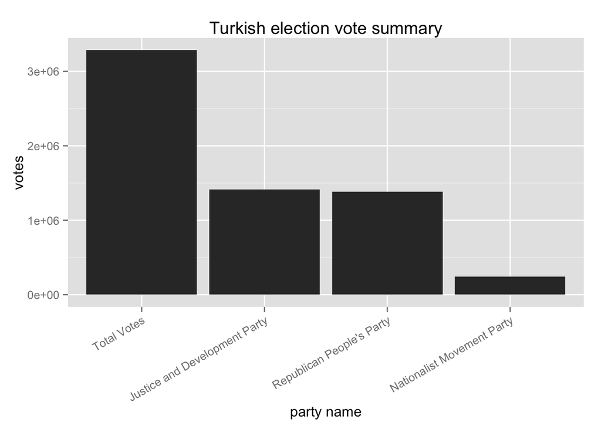

*Total number of akp and chp votes*

```r
ankara$akp_plus_chp=(ankara$akp_oy+ankara$chp_oy)
```

*Difference between akp and chp votes*

```r
ankara$akp_minus_chp=(ankara$akp_oy-ankara$chp_oy)
```

*Calculate the AKP vote share*

```r
ankara$akp_vote_share=(ankara$akp_oy/ankara$akp_plus_chp)
```

*Divide valid votes and registered votes gives the turnout rate*

```r
ankara <- mutate(ankara, turn_out_rates = gecerli_oy/kayitli_secmen)
ankara <- mutate(ankara, turn_out_rates2 = kullanilan_toplam_oy/kayitli_secmen)
```

*Make a scatter plot regarding akp vote share and turnout rates*

```
## geom_smooth: method="auto" and size of largest group is >=1000, so using gam with formula: y ~ s(x, bs = "cs"). Use 'method = x' to change the smoothing method.
```

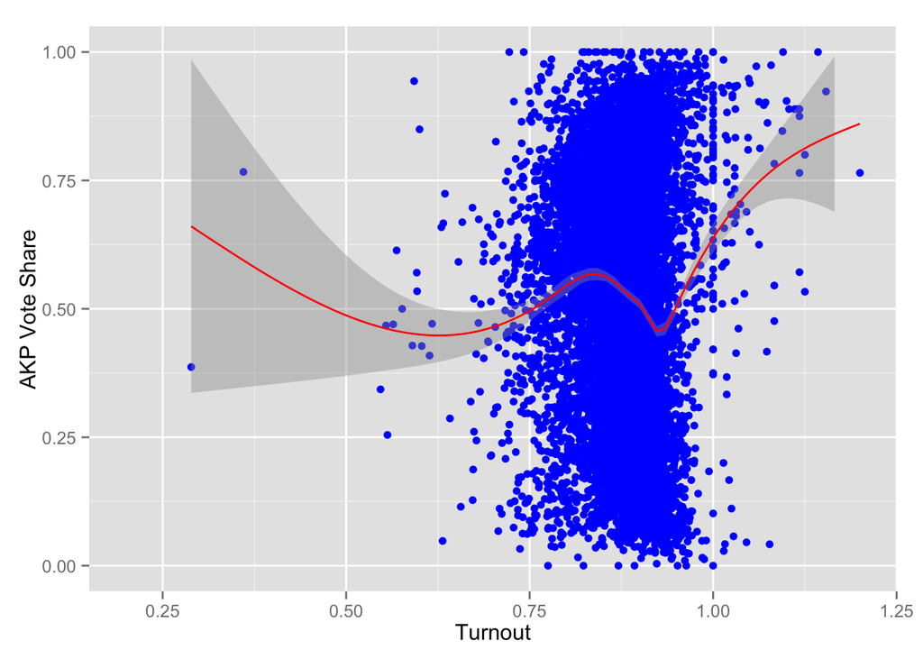

```r
pl2 <- ggplot(ankara, aes(x=turn_out_rates, y=akp_vote_share),
              ggtitle="AKP Vote Share vs turnout")
pl2 + geom_point(size=2, colour="blue") +xlim(0.2, 1.2) +ylim(0, 1) +
  xlab("Turnout") +
  ylab("AKP Vote Share") +
  stat_smooth(color="red")
```

*Divide invalid votes and actual votes gives the invalid ballot share*

```r
ankara$ballot=(ankara$gecersiz_oy/ankara$kullanilan_toplam_oy)
```

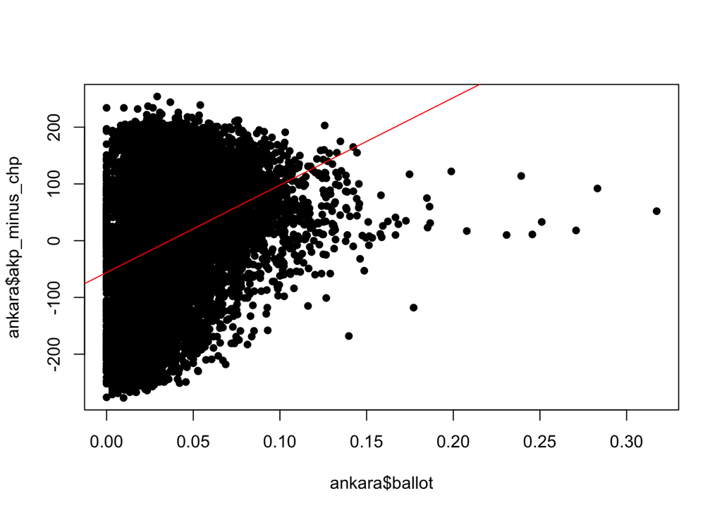

```r
par(pch=16)
plot(ankara$ballot, ankara$akp_minus_chp)
abline(lm(ankara$akp_minus_chp~ankara$ballot), col="red")
```

**Objective**

An objective and reasonable way to determine whether a fraud is commited will be the data analysis by statistical methods if the dataset of the voting result is acquired. Often this process requires a significant amount of time. This research is focusing on the dataset of Turkish Mayoral Election in 2014, which is acquired by Dr. Andi Shehu from Hunter College of CUNY. In the election, There are several parties competing for the leadership position in Turkey, but the biggest parties that have the most supporters are AKP and CHP, in which AKP is the incumbent party and CHP is the main opposition party.

After the dataset is obtained, it needs to be translated into English, understood clearly, and cleaned. In the whole dataset, there are several variables which have significance in the research: the total number of registered votes, the number of valid votes, the number of invalid votes, and the number of votes for AKP and CHP. In the process of cleaning the data, all of the N/A values need to be omitted.

For the next step, different algorithms are used to find the relationship among variables. This research uses R as its programming language. A number of regression methods will be applied to different variables, such as simple linear regression, multivariable linear regression and logistic regression. The first step will be fitting the variables using the specific model, and the data frame will be splited into training and testing datasets. After the validation of the model such as cross validation, a prediction will be run in the testing dataset to analyze if the model is a good fit. Following the prediction is the error analysis, including interpreting R square value, RMSE, and other indicative values)

Last but not least, the models will be visualized into specific graphes in R. The graphes will possibly include the bar graphes that show the comparison between vote shares of different parties, scatter plots with fitted line that focus on the relationship between vote share and turnout rate or invalid ballot shares, and other forms of graphes that will demonstrate the new findings of the variable relationship and comparison.

**Timeline**

All time: Read papers from R blogger about R programming techniques and different perspectives of data analysis; Contact Dr. Andi Shehu and Dr. Sergey Samsonau for possible directions and help about R.

Feb12 Finish linear regression

Feb26 Finish most of the other regression methods and error analyses

Mar11 Reproduce most of the reasonable visualizations that correspond to the fitted models

Mar28 Think about methods to define and quantify the confidence level of fraud in the election

Apr8 Develop a preliminary quantitative indicator and test it

Apr29 Try different ways to create the indicator, discuss with mentors and solidify the idea

May13 Reach a preliminary conclusion, find another dataset about an election, and use the similar method to analyze

May27 Final report due, start to make final presentation

Jun3 Finish the presentation

Jun10 Final presentation